# Compositional analysis of The Human Protein Atlas

This vignette from the R package JMDplots version 1.2.5 shows compositional metrics and phylostrata for proteins that are differentially expressed in cancer compared to normal tissue (data from [The Human Protein Atlas](https://www.proteinatlas.org)). The analysis is described in more detail in a paper ([Dick, 2020](https://doi.org/10.1002/cso2.1007)). Abbreviations:

- *Z*<sub>C</sub> – average oxidation state of carbon.
- *n*<sub>H<sub>2</sub>O</sub> – stoichiometric hydration state per residue ([Dick et al., 2020](https://doi.org/10.5194/bg-17-6145-2020)) computed using the **QEC** basis species (glutamine, glutamic acid, cysteine, H<sub>2</sub>O, O<sub>2</sub>).
- PS – phylostratum; *n*<sub>AA</sub> – protein length; MW – molecular weight per residue.

Gene ages, expressed as phylostratum numbers, are taken from [Trigos et al., 2017](https://doi.org/10.1073/pnas.1617743114) (TPPG17) or [Liebeskind et al, 2016](https://doi.org/10.1093/gbe/evw113) (LMM16).

```r
datasets <- pdat_HPA()
```

Differences are calculated as (median value for up-regulated proteins) - (median value for down-regulated proteins), except for phylostrata, where mean values are used. Dashed lines enclose the 50% credible region for highest probability density.

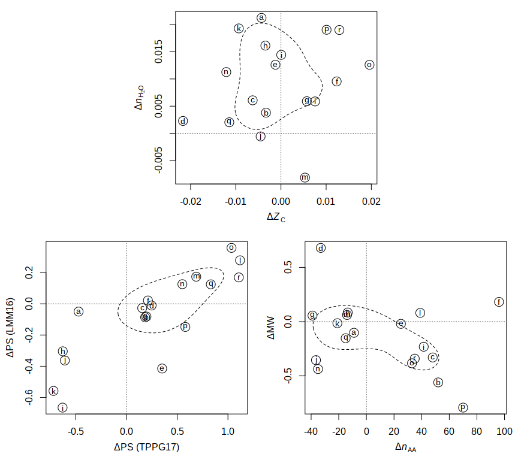

In the table, values of Δ*Z*<sub>C</sub> and Δ*n*<sub>H<sub>2</sub>O</sub> are multiplied by 1000, values of ΔPS and ΔMW are multiplied by 100, and negative values are shown in bold. Abbreviations:

- *n*<sub>down</sub> – number of down-regulated proteins; *n*<sub>up</sub> – number of up-regulated proteins.

|  |  |  |  |  |  | **TPPG17** | **LMM16** |  |  |
| --- | --- | --- | --- | --- | --- | --- | --- | --- | --- |
| set | reference (description) | *n*<sub>down</sub> | *n*<sub>up</sub> | Δ*Z*<sub>C</sub> | Δ*n*<sub>H<sub>2</sub>O</sub> | ΔPS | ΔPS | Δ*n*<sub>AA</sub> | ΔMW |
| a | `HPA19` (breast cancer / breast) | 77 | 512 | **-4** | 21 | **-47** | **-5** | **-9** | **-10** |
| b | `HPA19` (cervical cancer / cervix, uterine) | 367 | 207 | **-3** | 4 | 20 | **-8** | 52 | **-56** |
| c | `HPA19` (colorectal cancer / colon) | 263 | 423 | **-6** | 6 | 16 | **-3** | 48 | **-33** |
| d | `HPA19` (endometrial cancer / endometrium 1) | 117 | 263 | **-22** | 2 | 25 | **-1** | **-33** | 68 |
| e | `HPA19` (glioma / cerebral cortex) | 95 | 209 | **-1** | 13 | 35 | **-41** | 25 | **-2** |
| f | `HPA19` (head and neck cancer / salivary gland) | 1075 | 534 | 12 | 10 | 21 | 2 | 96 | 18 |
| g | `HPA19` (liver cancer / liver) | 51 | 423 | 6 | 6 | 18 | **-9** | **-39** | 6 |
| h | `HPA19` (lung cancer / lung) | 402 | 268 | **-3** | 16 | **-63** | **-30** | **-14** | 8 |
| i | `HPA19` (lymphoma / lymph node) | 446 | 69 | 0 | 14 | **-63** | **-67** | 42 | **-23** |
| j | `HPA19` (melanoma / skin 1) | 180 | 516 | **-5** | **-1** | **-61** | **-36** | **-36** | **-35** |
| k | `HPA19` (ovarian cancer / ovary) | 151 | 1075 | **-9** | 19 | **-72** | **-56** | **-21** | **-1** |
| l | `HPA19` (pancreatic cancer / pancreas) | 361 | 293 | 8 | 6 | 112 | 28 | 39 | 8 |
| m | `HPA19` (prostate cancer / prostate) | 621 | 197 | 5 | **-8** | 69 | 17 | **-14** | 6 |
| n | `HPA19` (renal cancer / kidney) | 939 | 97 | **-12** | 11 | 55 | 13 | **-35** | **-44** |
| o | `HPA19` (stomach cancer / stomach 1) | 1963 | 111 | 20 | 13 | 104 | 36 | 33 | **-38** |
| p | `HPA19` (testis cancer / testis) | 1202 | 123 | 10 | 19 | 58 | **-15** | 70 | **-79** |
| q | `HPA19` (thyroid cancer / thyroid gland) | 784 | 387 | **-11** | 2 | 83 | 12 | **-15** | **-15** |
| r | `HPA19` (urothelial cancer / urinary bladder) | 1050 | 94 | 13 | 19 | 111 | 17 | 35 | **-34** |

## Data Sources

**a**. – **r**. Human Protein Atlas (Uhlén et al., 2015).

## References

Uhlén M, Fagerberg L, Hallström BM, Lindskog C, Oksvold P, Mardinoglu A, Sivertsson Å, Kampf C, Sjöstedt E, Asplund A, Olsson I, Edlund K, Lundberg E, Navani S, Szigyarto CA-K, Odeberg J, Djureinovic D, Takanen JO, Hober S, Alm T, Edqvist P-H, Berling H, Tegel H, Mulder J, Rockberg J, Nilsson P, Schwenk JM, Hamsten M, Feilitzen K von, Forsberg M, Persson L, Johansson F, Zwahlen M, Heijne G von, Nielsen J, Pontén F. 2015. Tissue-based map of the human proteome. *Science* 347:1260419. DOI: 10.1126/science.1260419.